# Household level share model on bath tissue

TK

Feb 21st, 2017

# Objectives

- Testing household level share model by Bowen with bath tissue category
- Data
  - Category: Bath tissue
  - Date: ‘2015-06-20’ and ‘2017-01-20’
  - Data split:
    - Training: 62 weeks
    - Validation: 21 weeks
    - After training, the predictions are adjusted for 21 weeks by simple scaling
  - Stores: 307, 541, 549
    - Three stores with the fewest added items compared to deleted items

# Prediction vs actual

## Baseline model

Baseline model assumes that the same amount will be sold per week and scaled accordingly. This baseline model prediction is compared against the observed sales after mod change. X axis show the *actual* quantity sold after mod change (validation) and Y axis show the *predicted* quantity from the baseline model. The blue line has the slope 1 and intercept 0.

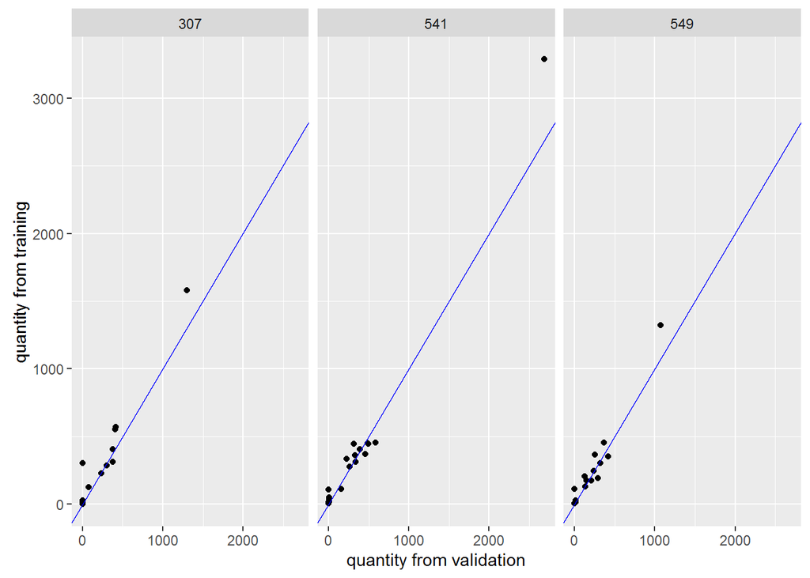

## Baseline model scaled by available weeks

Some items are available for all weeks and some are not. So, I scaled the sales simply assuming that the weekly sales will be constant. If an item is available in $k$ weeks, which is less than the full $n$ weeks , the observed sales quantity $q$ is adjusted by
$$q / k * n$$

Both sales in training period and sales in validation period are adjusted and compared as follows.

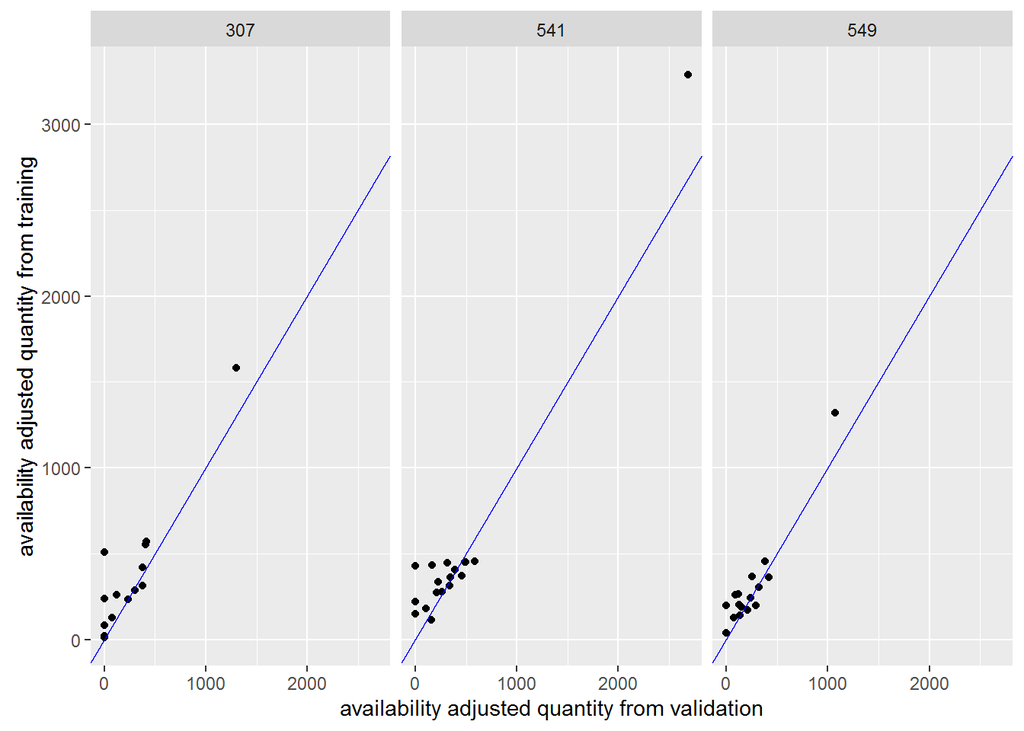

## Household level share model

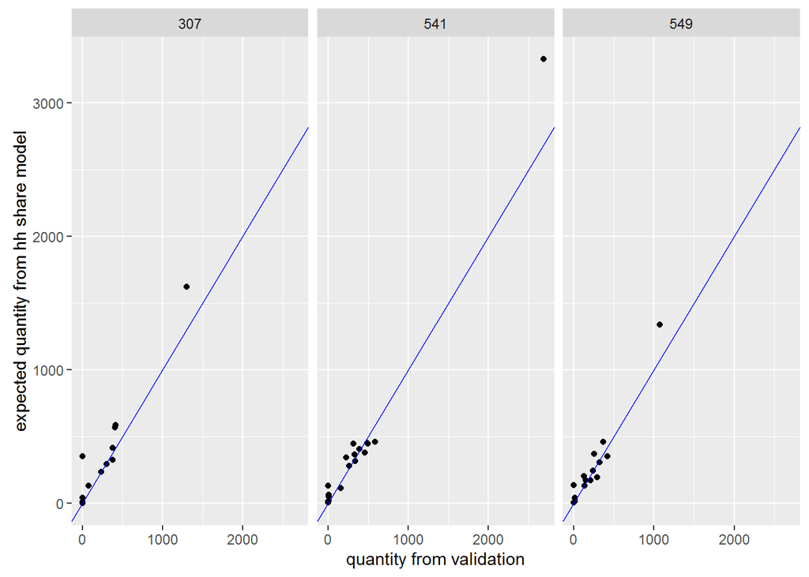

## Household level share model adjusted by available week

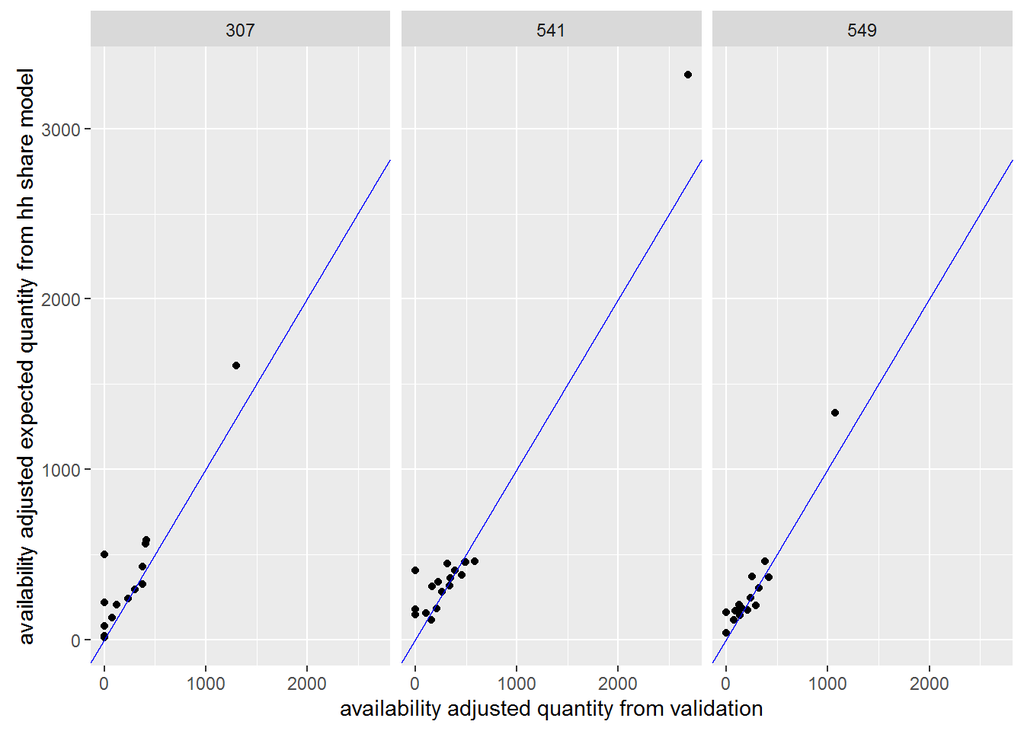

# Comparing different predictions

## Baseline vs household level share model

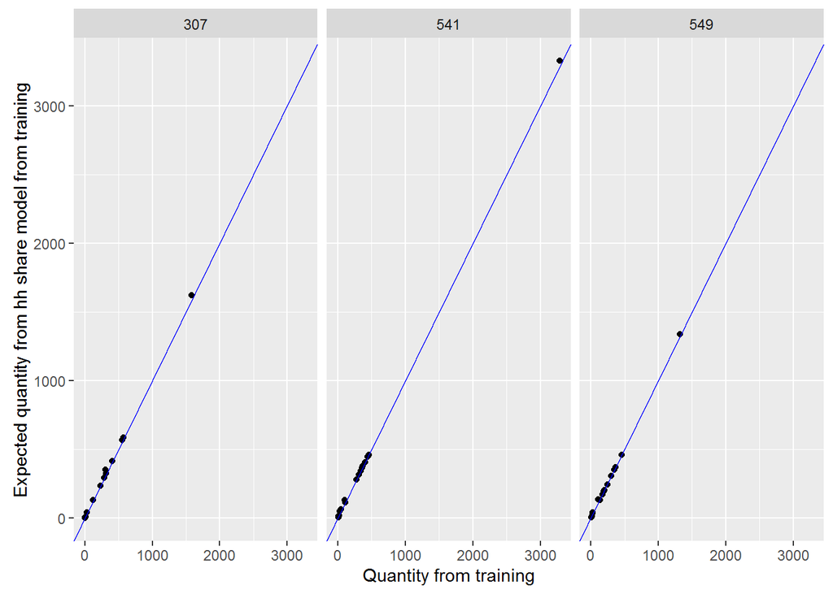

## Baseline vs household level share model adjusted by availability

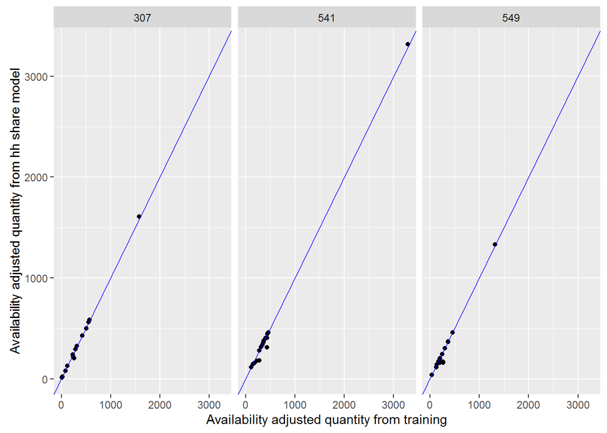